# USL Project 1: Global Energy Mix Regimes

Ondřej Marvan, 477001

2026-01-19

# USL Project 1

# List of Content

1. Intorduction
2. Data Preparation & Cleaning
3. Merging Research Data (GDP, CO2, Density)
4. Exploratory Data Analysis (EDA) 4.1. Global Energy Evolution
5. Determining Optimal Clusters (Quality)
6. K-means Clustering Execution
7. Improving Clusters: Robustness & Taxonomy 7.1. PAM Clustering 7.2. Hierarchical Dendrogram
8. Geographical Mapping
9. Profiling & Final Interpretation
10. Case Study: Czech Republic Progress & Cluster-Based Forecasting 10.1. Energy Mix Evolution in Czechia (1990–2023) 10.2. Forecasting Solar Transition via Cluster Logic
11. Improved Clustering: Single Year (2023)

# 1. Introduction

The objective of this project is to identify “Energy Regimes” by clustering countries based on their per-capita energy mix. I also investigated how these clusters relate to economic wealth (GDP), environmental impact (CO2), and physical constraints (Population Density). CO2 emissions and population density data are from the same source as energy data, while GDP data is sourced from the World Bank. All added additional data to create a more robust clustering model. Further, I decided to focus on Czech Republic as a further expansion of the project to analyze its energy transition and forecast future solar capacity using cluster-based logic.

# 2. Data Preparation & Cleaning

First of all, I load the primary energy dataset and filter for individual countries, removing regional aggregates (Europe, Asia, etc.).

```r
energy_raw <- read.csv("per-capita-energy-stacked.csv", stringsAsFactors = FALSE)

# Filter for countries, replace NAs, and excluding ICELAND (outlier that always steels its own cluster, 90% of its energy mix is from renewables - unrealistic for clustering and dissimilar to other countries, further small population merged with geothermal and hydro source of energy).
energy_clean <- energy_raw %>%
  filter(Code != "" & !is.na(Code)) %>% # Keep only countries with ISO codes.
  filter(Entity != "Iceland") %>%  # Key improvement: Removing extreme energy outlier (described above).
  mutate(across(4:11, ~replace_na(., 0))) %>% # Replace NAs with 0 for energy sources, mutates columns 4 to 11.
  rename(
    Coal = coal_per_capita__kwh, Oil = oil_per_capita__kwh, Gas = gas_per_capita__kwh,
    Nuclear = nuclear_per_capita__kwh__equivalent, Hydropower = hydro_per_capita__kwh__equivalent,
    Wind = wind_per_capita__kwh__equivalent, Solar = solar_per_capita__kwh__equivalent,
    `Other renewables` = other_renewables_per_capita__kwh__equivalent
  )

# Define columns for clustering
energy_cols <- c("Coal", "Oil", "Gas", "Nuclear", "Hydropower", "Wind", "Solar", "Other renewables") # Simplification of column names for later use, especially in charts.

summary(energy_clean) # data summary
```

```
##     Entity              Code                Year           Coal
##  Length:5865        Length:5865        Min.   :1965   Min.   :    0.0
##  Class :character   Class :character   1st Qu.:1982   1st Qu.:    0.0
##  Mode  :character   Mode  :character   Median :1997   Median :  618.8
##                                        Mean   :1996   Mean   : 4368.6
##                                        3rd Qu.:2011   3rd Qu.: 5638.0
##                                        Max.   :2024   Max.   :96194.4
##       Oil                Gas            Nuclear          Hydropower
##  Min.   :     0.0   Min.   :     0   Min.   :    0.0   Min.   :    0.0
##  1st Qu.:   511.1   1st Qu.:     0   1st Qu.:    0.0   1st Qu.:    0.0
##  Median :  7604.0   Median :  1655   Median :    0.0   Median :  201.2
##  Mean   : 12535.7   Mean   :  8142   Mean   : 1121.9   Mean   : 2245.4
##  3rd Qu.: 17464.6   3rd Qu.:  8455   3rd Qu.:   34.7   3rd Qu.: 1387.4
##  Max.   :156814.9   Max.   :288359   Max.   :24744.8   Max.   :87720.1
##       Wind             Solar           Other renewables
##  Min.   :   0.00   Min.   :   0.0000   Min.   :   0.00
##  1st Qu.:   0.00   1st Qu.:   0.0000   1st Qu.:   0.00
##  Median :   0.00   Median :   0.0000   Median :   0.00
##  Mean   : 166.50   Mean   :  62.3079   Mean   : 210.53
##  3rd Qu.:   1.98   3rd Qu.:   0.2034   3rd Qu.:  90.94
##  Max.   :9315.29   Max.   :4584.5957   Max.   :7658.23
```

```r
dim(energy_raw) # raw data
```

```
## [1] 6585   11
```

```r
dim(energy_clean) # cleaned data
```

```
## [1] 5865   11
```

We’ve got 5865 values in 11 columns. Data are more or less ready for EDA.

# 3. Merging Research Data (GDP, CO2, Density)

Energy mix data looks good but quite boring to analyze them standalone, why not to add some socio-economic context? I downloaded GDP per capita, CO2 emissions per capita, and Population Density datasets from the same source as energy data (World in Data and World bank). I merged them into a single “master_data” dataframe for further analysis.

```r
gdp_data <- read.csv("gdp-per-capita-worldbank.csv")
co2_data <- read.csv("co2-emissions-per-capita.csv")
pop_data <- read.csv("population-density.csv")

master_data <- energy_clean %>% # left join
  left_join(gdp_data %>% select(Entity, Code, Year, GDP = 4), by = c("Entity", "Code", "Year")) %>%
  left_join(co2_data %>% select(Entity, Code, Year, CO2 = 4), by = c("Entity", "Code", "Year")) %>%
  left_join(pop_data %>% select(Entity, Code, Year, Pop_Density = 4), by = c("Entity", "Code", "Year"))
```

# 4. Exploratory Data Analysis (EDA)

## 4.1. Global Energy Evolution

Before clustering, we look at the historical trend of global energy consumption.

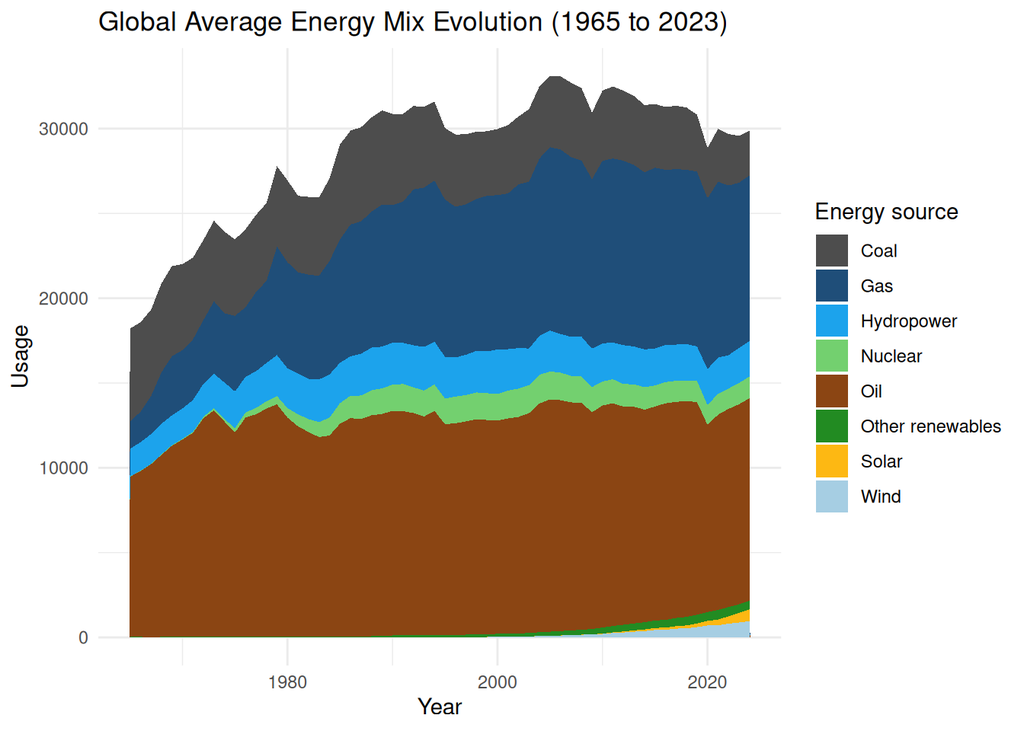

```r
energy_colors <- c( # Trying to fit color palette each energy source.
  Coal      = "#4D4D4D",
  Oil       = "#8B4513",
  Gas       = "#1F4E79",
  Nuclear   = "#73D06F",
  Hydropower= "#1CA3EC",
  Wind      = "#A6CEE3",
  Solar     = "#FDB813",
  `Other renewables` = "#228B22",
  Other     = "#BDBDBD"
)

master_data %>%
  group_by(Year) %>%
  summarise(across(all_of(energy_cols), mean)) %>%
  pivot_longer(-Year, names_to = "Source", values_to = "Usage") %>%
  ggplot(aes(x = Year, y = Usage, fill = Source)) +
  geom_area() +
  scale_fill_manual(values = energy_colors) +
  theme_minimal() +
  labs(
    title = "Global Average Energy Mix Evolution (1965 to 2023)",
    fill = "Energy source"
  )
```

By analyzing the global energy mix from 1965 to the present, it’s possible to observe that the total volume of energy used per person has grown significantly.

I noticed that while Solar and Wind have grown rapidly in recent years, they appear as a new layer being added on top of Fossil Fuels (Oil, Coal, and Gas). Even as countries innovate, our global dependence on traditional sources has not yet seen a major absolute decline, just a slight phase-out. This visual evidence suggests that the challenge for the countries I am clustering is not just ‘getting cleaner,’ but managing an ever-increasing appetite for energy as they grow wealthier.

Result above is taking to consideration demographic changes (per-capita basis). Below is displayed the absolute energy consumption growth (not per-capita).

[figure not shown]

For more in depth analysis of the current situation, check https://app.electricitymaps.com/map/.

## 4.2. Correlation & Hypothesis Testing

Hypothesis: Rich countries (high GDP) are the leaders in green energy.

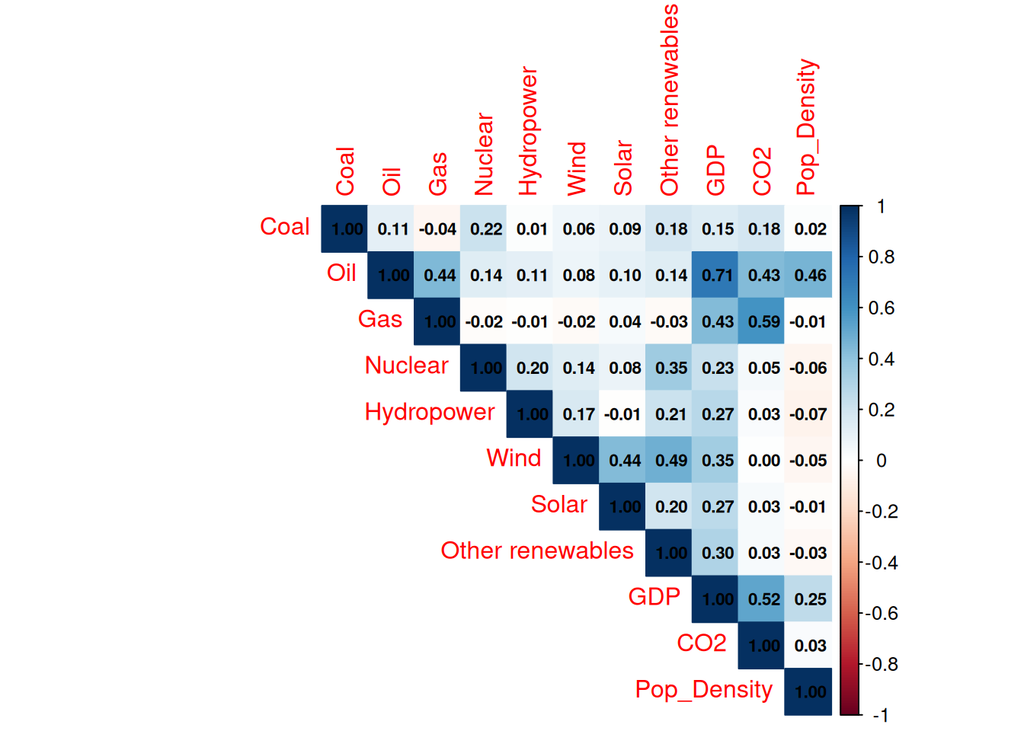

```r
# Correlation Matrix
cor_vars <- c(energy_cols, "GDP", "CO2", "Pop_Density") # Vectors to be included (all).
res_cor <- cor(master_data[, cor_vars], use = "complete.obs") # Uses only rows where all variables have non-missing values.
corrplot(res_cor, method = "color", type = "upper", addCoef.col = "black", number.cex = 0.7) # Creates correlation plot (heatmap).
```

# 5. Determining Optimal Clusters (Quality)

Evaluation of the energy variables only to find the “Natural Taxonomies” of energy use.

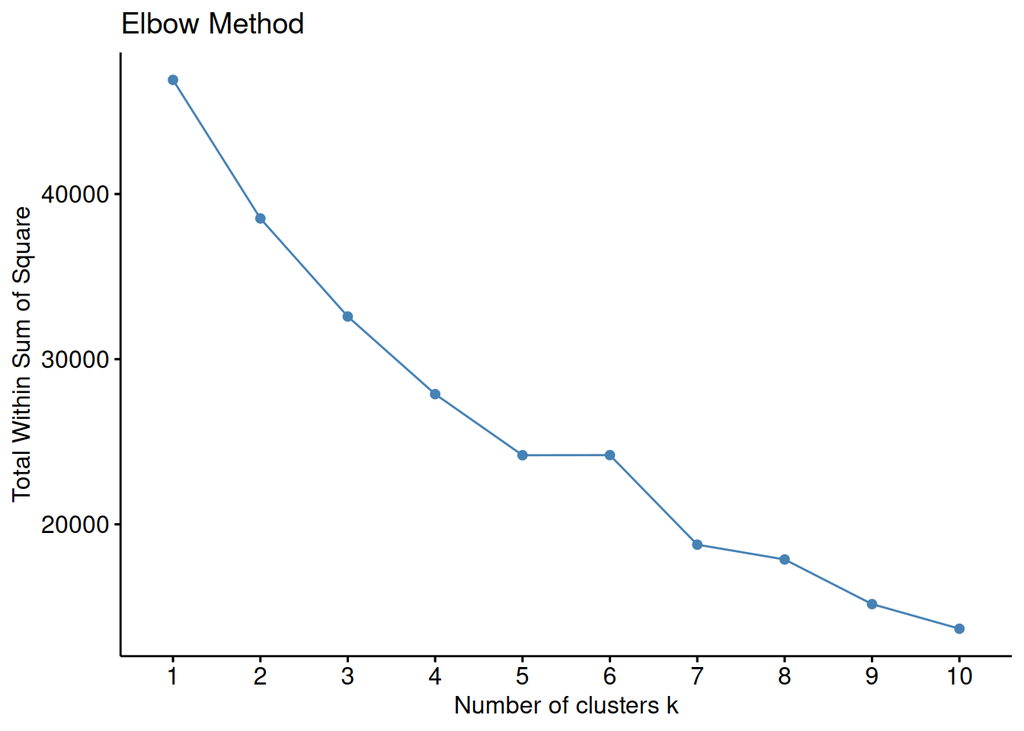

```r
energy_scaled <- scale(master_data[, energy_cols])

fviz_nbclust(energy_scaled, kmeans, method = "wss") + labs(title = "Elbow Method")
```

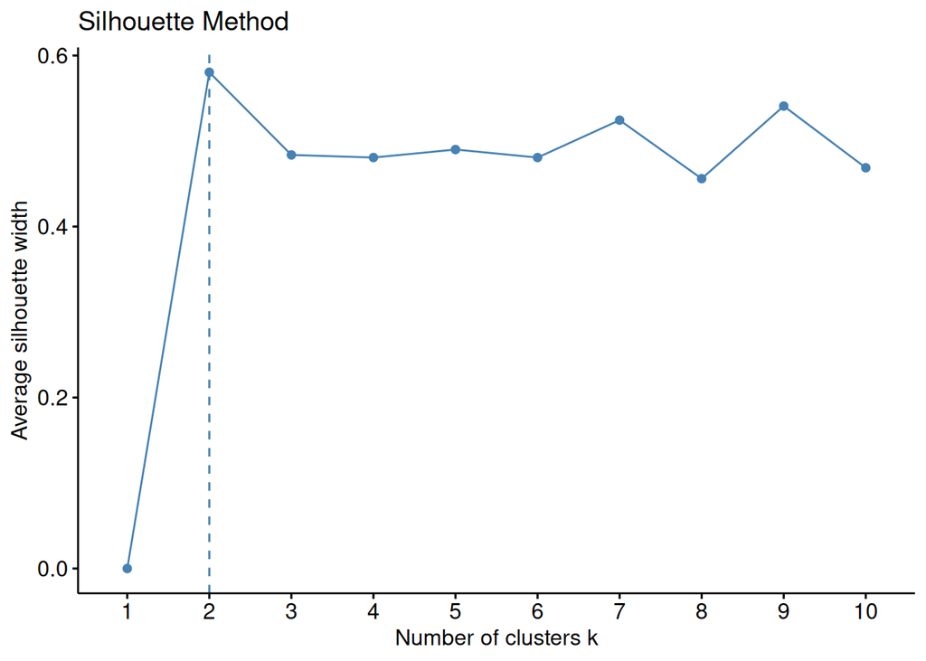

```r
fviz_nbclust(energy_scaled, kmeans, method = "silhouette") + labs(title = "Silhouette Method")
```

*Interpretation:* While Silhouette suggests k=2 (a simple Developed vs. Developing split), the Elbow method supports k=5. Following Classes, I choose k=5 to provide a more meaningful taxonomy, allowing us to distinguish between different high-income regimes (e.g., Oil-heavy vs. Green-heavy).

# 6. K-means Clustering Execution

```r
set.seed(123)
km_res <- kmeans(energy_scaled, centers = 5, nstart = 25)
master_data$Cluster <- as.factor(km_res$cluster) # Assign cluster labels to the master_data dataframe.
```

# 7. Improving Clusters: Robustness & Taxonomy

## 7.1. PAM Clustering and Dendrogram

```r
# Scaling the data
energy_scaled <- scale(master_data[, energy_cols]) # Standardizing energy mix data for clustering.

# PAM (K-medoids) for robustness
# Unlike K-means, PAM is not influenced by outliers
set.seed(123) # For reproducibility.
pam_res <- pam(energy_scaled, k = 5)
master_data$Cluster <- as.factor(pam_res$clustering) # Assign PAM cluster labels to the master_data dataframe and overwrite previous K-means labels.
```

## 7.2. Hierarchical Dendrogram

The dendrogram shows how countries group together based on energy mix similarity.

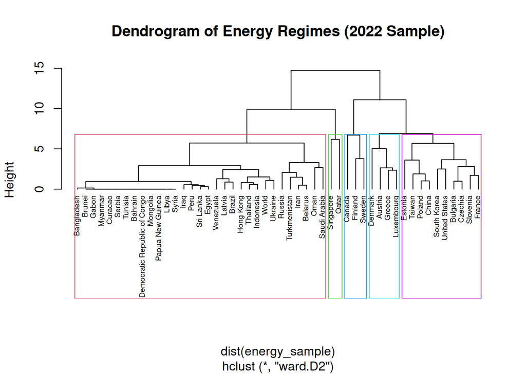

```r
# Take a sample from 2022 for readable dendrogram (full dataset too large)
set.seed(123)
data_2022 <- master_data %>% filter(Year == 2022)
sample_rows <- sample(nrow(data_2022), 50) # 50 countries for readability
energy_sample <- scale(data_2022[sample_rows, energy_cols])
rownames(energy_sample) <- data_2022$Entity[sample_rows]

# Hierarchical clustering
hc <- hclust(dist(energy_sample), method = "ward.D2")

# Plot dendrogram with 5 clusters marked
plot(hc, cex = 0.6, hang = -1, main = "Dendrogram of Energy Regimes (2022 Sample)")
rect.hclust(hc, k = 5, border = 2:6) # Draw boxes around 5 clusters
```

I used PAM (K-medoids) to ensure my clusters weren’t skewed by extreme outliers. Unlike K-means, PAM uses actual ‘representative’ countries as centers, making my five energy regimes more realistic.

The Dendrogram is acting as a tree for energy strategies. It shows that the ‘Green Leaders’ and ‘Nuclear/Industrial’ groups are closely related branches, while the ‘Fossil Giants’ belong to a completely different lineage. This validates that my five clusters represent distinct, natural categories of how nations power their economies.

# 8. Geographical Mapping

I visualize the distribution of our 5 clusters across the world and zoom in on specific regions.

[figure not shown]

```r
# Join results with world map coordinates
world_coords <- map_data("world")

map_ready_data <- master_data %>%
  filter(Year == 2022) %>%
  mutate(region = case_when(
    Entity == "Czechia" ~ "Czech Republic",
    Entity == "United States" ~ "USA",
    Entity == "United Kingdom" ~ "UK",
    TRUE ~ Entity
  ))

map_joined <- world_coords %>%
  left_join(map_ready_data, by = "region")

# Plotting the whole world
ggplot(map_joined, aes(x = long, y = lat, group = group, fill = Cluster)) +
  geom_polygon(color = "white", size = 0.1) +
  scale_fill_brewer(palette = "Set1", na.value = "grey90") +
  theme_minimal() +
  labs(title = "Global Energy Regimes (2022)",
       subtitle = "5 clusters identified by energy mix, wealth, and emissions",
       fill = "Cluster") +
  theme(axis.text = element_blank(), axis.title = element_blank(), panel.grid = element_blank())
```

*Interpretation:* The global map reveals clear regional patterns in energy strategies.

*Cluster 1 (Red):* The Developing and Oil-Dependent World. I found that this is one of the largest groups, including India, Indonesia, most of Africa, Middle East, and South America. These countries are defined by either very low energy access or heavy dependence on petroleum exports. I interpret this as a mix of energy poverty and oil-based economies that lack diversified energy infrastructure.

*Cluster 2 (Blue):* The Coal-Dependent Transitional Economies. This small cluster contains South Africa and Kazakhstan. I distinguish this group because they rely heavily on coal to power their industries. They are in similar development stage with mining-based economies.

*Cluster 4 (Purple):* The Isolated Gas Economy. There are Turkmenistan, Saudi Arabia and Oman in this cluster. I interpret this as unique case - country with huge gas reserves but cut off from global markets by sanctions (or regimes), creating different energy pattern.

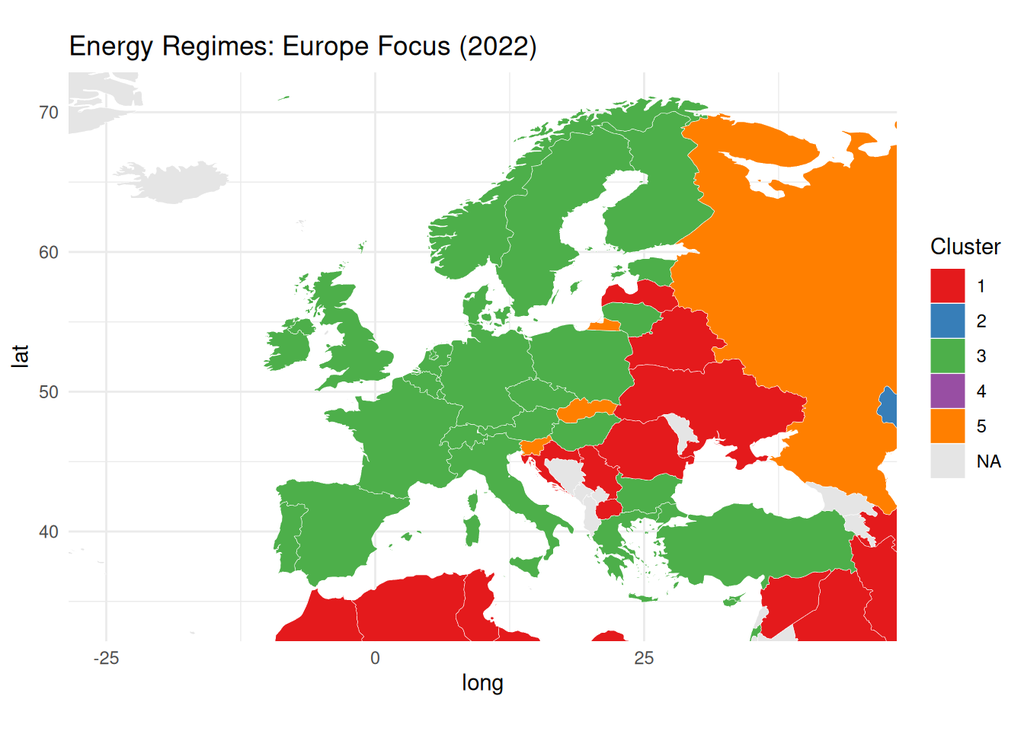

```r
# Join results with world map coordinates
world_coords <- map_data("world")

map_ready_data <- master_data %>%
  filter(Year == 2022) %>%
  mutate(region = case_when(
    Entity == "Czechia" ~ "Czech Republic", # FIX: Specifically for mapping Czechia
    Entity == "United States" ~ "USA",
    Entity == "United Kingdom" ~ "UK",
    TRUE ~ Entity
  ))

map_joined <- world_coords %>%
  left_join(map_ready_data, by = "region")

# Plotting the map with regional focus (Europe)
ggplot(map_joined, aes(x = long, y = lat, group = group, fill = Cluster)) +
  geom_polygon(color = "white", size = 0.1) +
  coord_fixed(xlim = c(-25, 45), ylim = c(34, 71), ratio = 1.3) + # Europe Zoom
  scale_fill_brewer(palette = "Set1", na.value = "grey90") +
  theme_minimal() +
  labs(title = "Energy Regimes: Europe Focus (2022)", fill = "Cluster")
```

```r
# Join results with world map coordinates
world_coords <- map_data("world")

map_ready_data <- master_data %>%
  filter(Year == 2022) %>%
  mutate(region = case_when(
    Entity == "Czechia" ~ "Czech Republic", # FIX: Specifically for mapping Czechia
    Entity == "United States" ~ "USA",
    Entity == "United Kingdom" ~ "UK",
    TRUE ~ Entity
  ))

map_joined <- world_coords %>%
  left_join(map_ready_data, by = "region")
```

# 9. Profiling & Final Interpretation

To conclude, we look at the average socio-economic profile of each cluster.

```r
master_data %>%
  group_by(Cluster) %>%
  summarise(
    Avg_GDP = mean(GDP, na.rm = TRUE),
    Avg_CO2 = mean(CO2, na.rm = TRUE),
    Avg_Solar = mean(Solar),
    Avg_Oil = mean(Oil)
  ) %>%
  arrange(desc(Avg_GDP))
```

```
## # A tibble: 5 × 5
##   Cluster Avg_GDP Avg_CO2 Avg_Solar Avg_Oil
##   <fct>     <dbl>   <dbl>     <dbl>   <dbl>
## 1 4        72296.   24.2      47.6   54530.
## 2 3        53939.    8.15    741.    18240.
## 3 5        40701.    9.00     41.6   20242.
## 4 2        32251.   11.4      15.6   18151.
## 5 1        15426.    4.60      8.69   4557.
```

The data reveals an ‘Energy Addition’ paradox. While wealth (GDP) provides the capital for Solar investment, it is more strongly linked to high-volume Oil and Gas consumption. This suggests that as countries get richer, they tend to add renewables on top of fossil fuels rather than immediately replacing them. Our clustering successfully separates the few ‘Green Leaders’ who have decoupled GDP from CO2 from the ‘Fossil Wealthy’ who have not.

# 10. Case Study: Czech Republic Progress & Cluster-Based Forecasting

In this section, I apply the theory from USL class: using cluster membership to develop an aggregated forecast that reduces variance and potentially lowers the Mean Square Error (MSE) compared to a single-country model.

## 10.1. Energy Mix Evolution in Czechia (1990–2023)

We first visualize the progress of Czechia’s energy sources. This chart shows the “decoupling” process (or lack thereof) from fossil fuels.

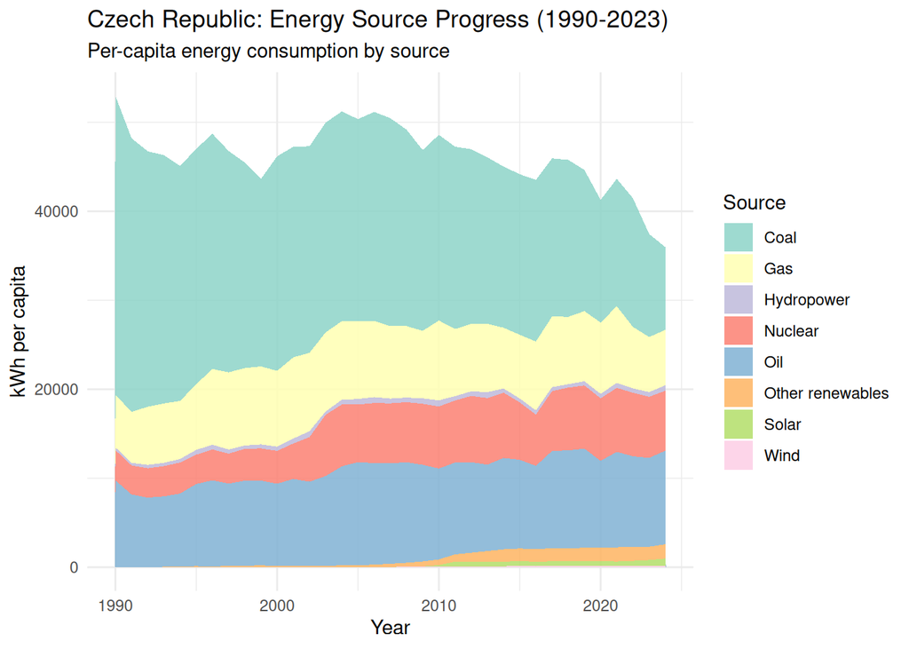

```r
# Filter for Czechia and pivot for visualization
czechia_progress <- master_data %>%
  filter(Entity == "Czechia" & Year >= 1990) %>%
  pivot_longer(cols = all_of(energy_cols), names_to = "Source", values_to = "Usage")

# Stacked Area Chart for Progress
ggplot(czechia_progress, aes(x = Year, y = Usage, fill = Source)) +
  geom_area(alpha = 0.85) +
  theme_minimal() +
  scale_fill_brewer(palette = "Set3") +
  labs(title = "Czech Republic: Energy Source Progress (1990-2023)",
       subtitle = "Per-capita energy consumption by source",
       y = "kWh per capita", x = "Year")
```

## 10.2. Forecasting Solar Transition via Cluster Logic

Instead of just looking at Czechia’s past, I use the “Aggregated Forecast” method where I identify Czechia’s cluster and use the cluster’s average growth rate to predict Czechia’s 2030 solar capacity.

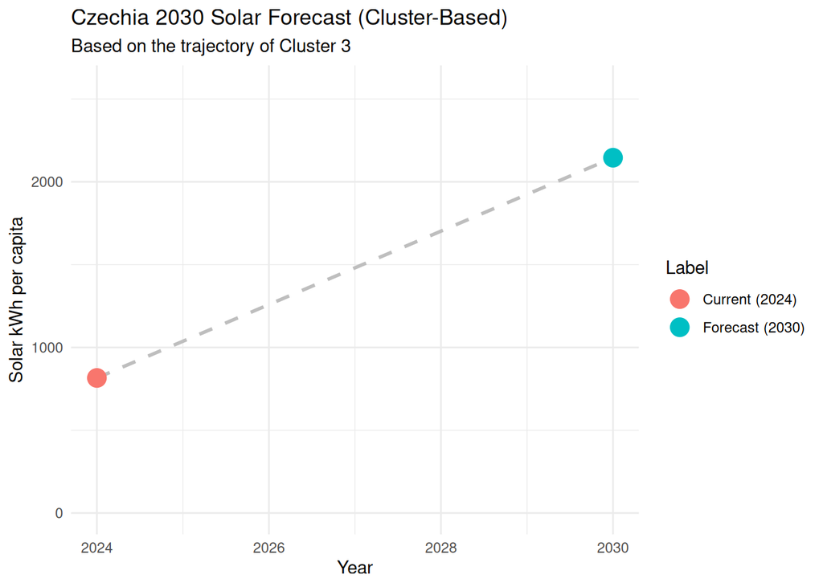

```r
# 1. Identify Czechia's current cluster (using the most recent year)
cze_latest <- master_data %>% filter(Entity == "Czechia" & Year == 2024)
target_cluster <- cze_latest$Cluster

# 2. Calculate average growth rate of Solar for the WHOLE cluster (2012-2022)
# This reduces the variance of the forecast
cluster_solar_growth <- master_data %>%
  filter(Cluster == target_cluster & Year >= 2012) %>%
  group_by(Entity) %>%
  arrange(Year) %>% # Ensures chronological order
  summarise(growth_rate = (last(Solar) - first(Solar)) / (last(Year) - first(Year))) %>%
  summarise(avg_cluster_growth = mean(growth_rate, na.rm = TRUE))

# 3. Apply this growth rate to Czechia for the next 6 years (to 2030)
current_solar <- cze_latest$Solar
forecast_years <- 2030 - 2024
projected_solar_2030 <- current_solar + (cluster_solar_growth$avg_cluster_growth * forecast_years)

# 4. Create the Forecast Plot
forecast_data <- data.frame(
  Year = c(2024, 2030),
  Solar = c(current_solar, projected_solar_2030),
  Label = c("Current (2024)", "Forecast (2030)")
)

ggplot(forecast_data, aes(x = Year, y = Solar)) +
  geom_line(linetype = "dashed", color = "grey", size = 1) +
  geom_point(aes(color = Label), size = 5) +
  theme_minimal() +
  ylim(0, max(projected_solar_2030) * 1.2) +
  labs(title = "Czechia 2030 Solar Forecast (Cluster-Based)",
       subtitle = paste("Based on the trajectory of Cluster", target_cluster),
       y = "Solar kWh per capita")
```

*Conclusion:* “If the Czech Republic maintains the adoption speed typical of its cluster, it will reachover 1000 kWh per capita in solar energy by 2030. This provides a data-driven benchmark for national energy goals.”

Last but not least (additional update of the project):

# 11. Improved Clustering: Single Year (2023)

## Why cluster only one year?

Clustering all years together (1965-2024) has a problem: the same country appears many times with different energy mixes. For example, Germany in 1970 looks very different from Germany in 2020. This means I haven’t really clustered countries - I have clustered country-years, which mixes historical data with current data.

A cleaner approach is to cluster only the recent year (2023). This gives snapshot of current energy regimes without historical noise.

```r
# Filter for 2023 only
data_2023 <- master_data %>% filter(Year == 2023)

# Check how many countries we have
cat("Number of countries in 2023:", nrow(data_2023), "\n")
```

```
## Number of countries in 2023: 107
```

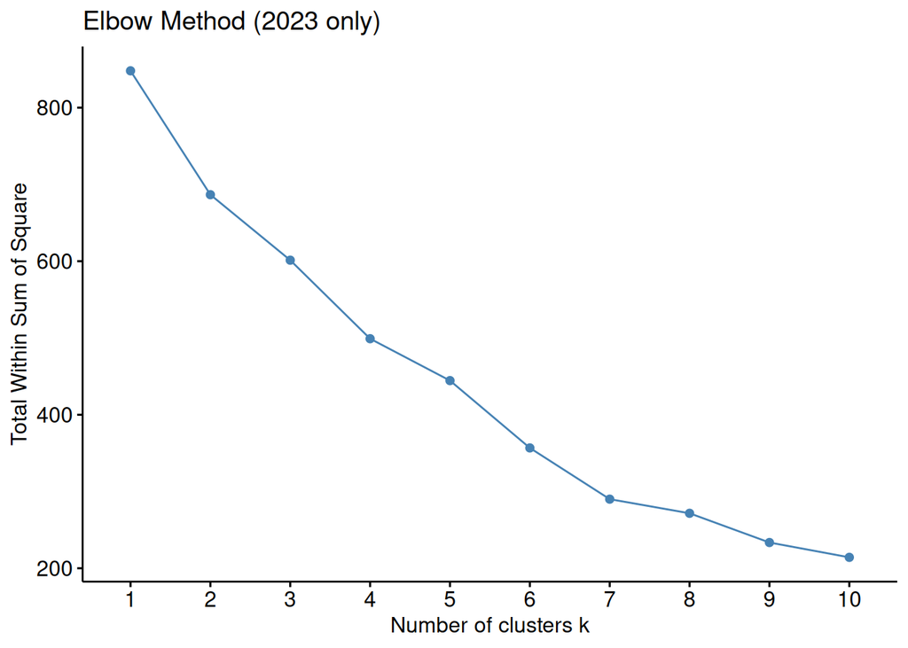

```r
# Scale the energy data
energy_scaled_2023 <- scale(data_2023[, energy_cols])

# Find optimal k using elbow and silhouette
fviz_nbclust(energy_scaled_2023, pam, method = "wss") + labs(title = "Elbow Method (2023 only)")
```

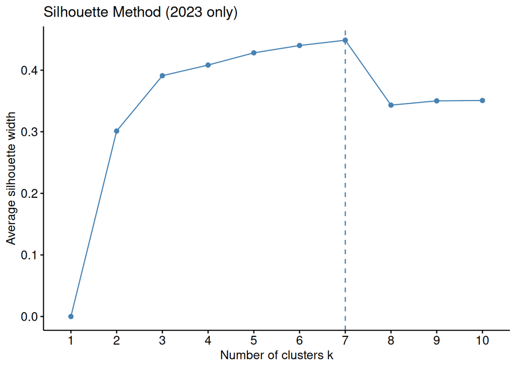

```r
fviz_nbclust(energy_scaled_2023, pam, method = "silhouette") + labs(title = "Silhouette Method (2023 only)")
```

```r
# PAM clustering on 2023 data
set.seed(123)
pam_2023 <- pam(energy_scaled_2023, k = 5)

# Add cluster labels
data_2023$Cluster_2023 <- as.factor(pam_2023$clustering)

# Cluster sizes
table(data_2023$Cluster_2023)
```

```
##
##  1  2  3  4  5
## 58  7 19 16  7
```

```r
# See the average profile of each cluster
data_2023 %>%
  group_by(Cluster_2023) %>%
  summarise(
    N = n(),
    Avg_GDP = mean(GDP, na.rm = TRUE),
    Avg_CO2 = mean(CO2, na.rm = TRUE),
    Avg_Coal = mean(Coal),
    Avg_Oil = mean(Oil),
    Avg_Nuclear = mean(Nuclear),
    Avg_Solar = mean(Solar)
  ) %>%
  arrange(desc(Avg_GDP))
```

```
## # A tibble: 5 × 8
##   Cluster_2023     N Avg_GDP Avg_CO2 Avg_Coal Avg_Oil Avg_Nuclear Avg_Solar
##   <fct>        <int>   <dbl>   <dbl>    <dbl>   <dbl>       <dbl>     <dbl>
## 1 5                7  63535.   21.0      171.  53013.          0      455.
## 2 3               19  59730.    5.34    1468.  16050.        866.    1199.
## 3 4               16  52988.    8.37    5314.  19047.       6544.    1266.
## 4 2                7  36154.    9.89   17033.  11956.        417.    1280.
## 5 1               58  18174.    4.17    1079.   3403.        172.      91.7
```

```r
# Where is Czechia in 2023?
czechia_2023 <- data_2023 %>% filter(Entity == "Czechia")
cat("Czechia belongs to Cluster:", as.character(czechia_2023$Cluster_2023), "\n")
```

```
## Czechia belongs to Cluster: 4
```

```r
# Who are Czechia's cluster peers?
data_2023 %>%
  filter(Cluster_2023 == czechia_2023$Cluster_2023) %>%
  select(Entity, GDP, Coal, Nuclear, Solar) %>%
  arrange(desc(GDP))
```

```
##                  Entity      GDP        Coal   Nuclear      Solar
## 1           Switzerland 82302.05    95.82255  6415.848 1271.40160
## 2         United States 74158.72  6624.04350  5791.954 1713.82430
## 3  United Arab Emirates 68577.54  2669.23020  7893.331 3301.18550
## 4               Belgium 62920.64  2371.74170  6856.714 1628.39150
## 5                Canada 57517.44  2620.08400  5488.094  521.16800
## 6               Finland 56246.44  4474.37900 14939.347  311.97232
## 7                France 54017.88   740.72560 12415.686  782.39470
## 8           South Korea 50414.21 16328.76700  8507.057 1566.50200
## 9              Slovenia 47868.39  3930.95560  6451.051 1133.34720
## 10               Israel 47527.15  3800.22850     0.000 2163.61280
## 11              Czechia 47509.52 11573.25200  6861.588  652.54390
## 12                Japan 45858.66 10131.87300  1519.071 1889.71940
## 13              Hungary 40368.59  1084.61410  4008.107 1743.69560
## 14               Russia 39887.34  7288.79200  3645.482   44.18662
## 15             Slovakia 39497.54  4965.64260  8103.330  267.41473
## 16             Bulgaria 33139.94  6319.40900  5801.024 1263.58760
```

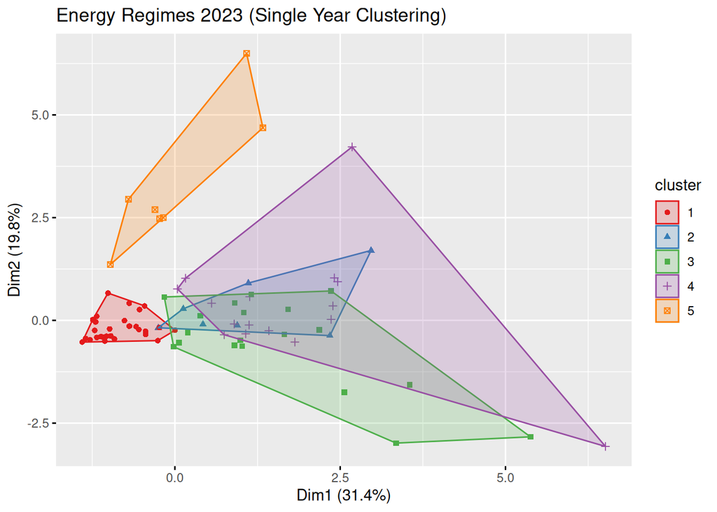

```r
# Visualize the 2023 clusters
fviz_cluster(pam_2023, data = energy_scaled_2023, geom = "point",
             ellipse.type = "convex", palette = "Set1",
             main = "Energy Regimes 2023 (Single Year Clustering)")
```

*Interpretation:* By clustering only 2023, we get a clear picture of today’s energy regimes. Each country appears exactly once, and the clusters represent current energy strategies - not a mix of past and present. This makes the results easier to interpret and more useful for policy discussions.

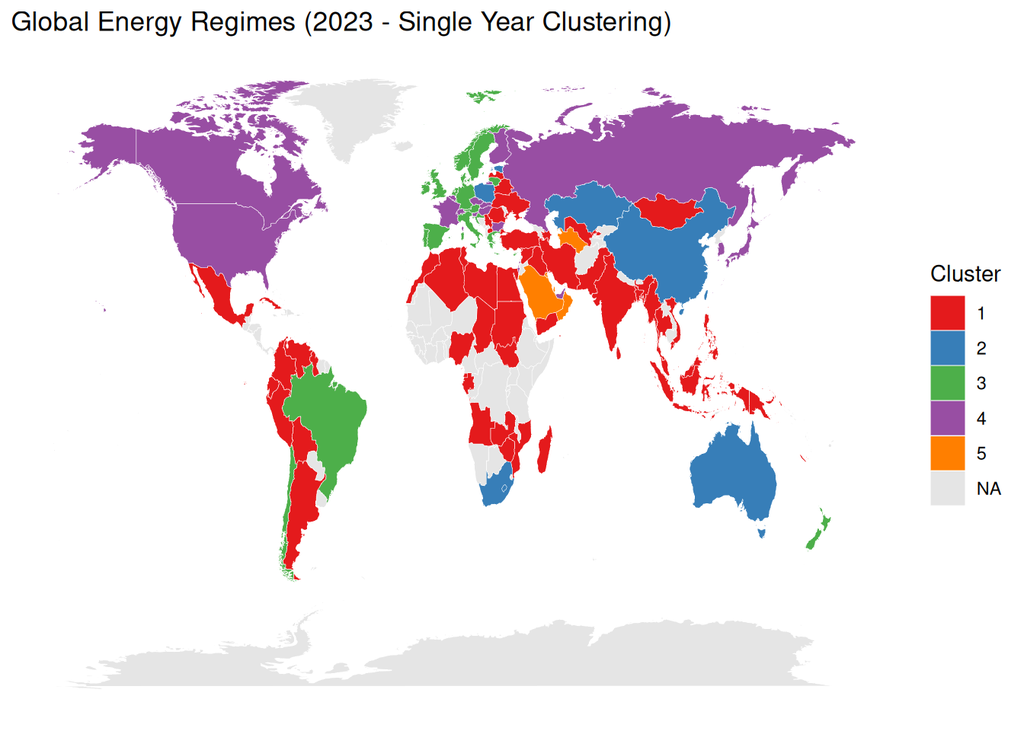

```r
# Map for 2023 clusters
map_ready_2023 <- data_2023 %>%
  mutate(region = case_when(
    Entity == "Czechia" ~ "Czech Republic",
    Entity == "United States" ~ "USA",
    Entity == "United Kingdom" ~ "UK",
    TRUE ~ Entity
  ))

# Join with world coordinates
world_coords <- map_data("world")
map_joined_2023 <- world_coords %>%
  left_join(map_ready_2023, by = "region")

# World map
ggplot(map_joined_2023, aes(x = long, y = lat, group = group, fill = Cluster_2023)) +
  geom_polygon(color = "white", size = 0.1) +
  scale_fill_brewer(palette = "Set1", na.value = "grey90") +
  theme_minimal() +
  labs(title = "Global Energy Regimes (2023 - Single Year Clustering)",
       fill = "Cluster") +
  theme(axis.text = element_blank(), axis.title = element_blank(), panel.grid = element_blank())
```

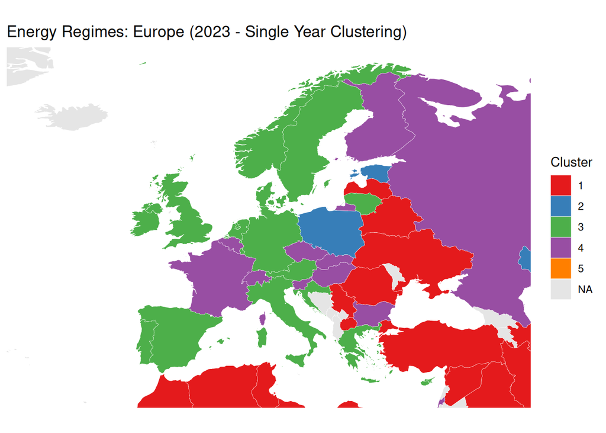

```r
# Europe zoom
ggplot(map_joined_2023, aes(x = long, y = lat, group = group, fill = Cluster_2023)) +
  geom_polygon(color = "white", size = 0.1) +
  coord_fixed(xlim = c(-25, 45), ylim = c(34, 71), ratio = 1.3) +
  scale_fill_brewer(palette = "Set1", na.value = "grey90") +
  theme_minimal() +
  labs(title = "Energy Regimes: Europe (2023 - Single Year Clustering)",
       fill = "Cluster") +
  theme(axis.text = element_blank(), axis.title = element_blank(), panel.grid = element_blank())
```

*Interpretation:* The maps show the geographical distribution of energy regimes based only on 2023 data. Compared to the original maps (which mixed all years), these clusters represent the current state of each country’s energy strategy.